# Predicting Wine Quality with Random Forest Algorithm

Prediction with Random Forest Algorithm

Havva Nur Elveren

10 October 2021

# Objective: Predicting Wine Quality

Can we predict wine quality based on its features such as acidity, alcohol, sugar or sulfate level? In this project, we’ll predict Wine Quality with looking at the value of different features of a wine. We’ll use a data set that has been collected from red wine variants of the Portuguese “Vinho Verde” wine. If quality is greater than 6.5 it is considered as good wine, otherwise it is considered as bad wine.

# Data Description:

- 1.6K Row with 12 Column. You can download the data from the link https://www.kaggle.com/uciml/red-wine-quality-cortez-et-al-2009

```r
library(kableExtra)

dt <- data.frame(Name = c("fixed.acidity", "volatile.acidity", "citric.acid", "residual.sugar", "chlorides", "free.sulfur.dioxide", "total.sulfur.dioxide",
"density", "pH", "sulphates", "alcohol", "quality"),
Description = c("most acids involved with wine or fixed or nonvolatile (do not evaporate readily)", "the amount of acetic acid in wine, which at too high of levels can lead to an unpleasant, vinegar taste", "found in small quantities, citric acid can add 'freshness' and flavor to wines", "the amount of sugar remaining after fermentation stops, it's rare to find wines with less than 1 gram/liter and wines with greater than", "the amount of salt in the wine", "the free form of SO2 exists in equilibrium between molecular SO2 (as a dissolved gas) and bisulfite ion; it prevents", "amount of free and bound forms of S02; in low concentrations, SO2 is mostly undetectable in wine, but at free SO2", "the density of water is close to that of water depending on the percent alcohol and sugar content", "describes how acidic or basic a wine is on a scale from 0 (very acidic) to 14 (very basic); most wines are between 3-4 on the", "a wine additive which can contribute to sulfur dioxide gas (S02) levels, wich acts as an antimicrobial and", "the percent alcohol content of the wine","Score between 0 and 10, if quality > 6.5 it's Good, otherwise it is Bad "))

dt %>%
  kbl() %>%
  kable_styling()
```

| Name | Description |
| --- | --- |
| fixed.acidity | most acids involved with wine or fixed or nonvolatile (do not evaporate readily) |
| volatile.acidity | the amount of acetic acid in wine, which at too high of levels can lead to an unpleasant, vinegar taste |
| citric.acid | found in small quantities, citric acid can add ‘freshness’ and flavor to wines |
| residual.sugar | the amount of sugar remaining after fermentation stops, it’s rare to find wines with less than 1 gram/liter and wines with greater than |
| chlorides | the amount of salt in the wine |
| free.sulfur.dioxide | the free form of SO2 exists in equilibrium between molecular SO2 (as a dissolved gas) and bisulfite ion; it prevents |
| total.sulfur.dioxide | amount of free and bound forms of S02; in low concentrations, SO2 is mostly undetectable in wine, but at free SO2 |
| density | the density of water is close to that of water depending on the percent alcohol and sugar content |
| pH | describes how acidic or basic a wine is on a scale from 0 (very acidic) to 14 (very basic); most wines are between 3-4 on the |
| sulphates | a wine additive which can contribute to sulfur dioxide gas (S02) levels, wich acts as an antimicrobial and |
| alcohol | the percent alcohol content of the wine |
| quality | Score between 0 and 10, if quality > 6.5 it’s Good, otherwise it is Bad |

## Step 1: Load the Libraries

```r
library(caret)
library(glmnet)
library(xgboost)
library(randomForest)
library(ISLR)
library(readxl)
library(pROC)
library(lattice)
library(e1071)
library(kknn)
```

```r
library(ggplot2)
library(multiROC)
library(MLeval)
library(AppliedPredictiveModeling)
library(corrplot)
library(Hmisc)
library(dplyr)
library(quantmod)
library(nnet)
library(NeuralNetTools)

library(mlbench)
library(caretEnsemble)
library(ranger)
library(C50)
```

## Step 2: Load the Data Set

```r
winedata <- read.csv("winequality-red.csv")
winedata <- data.frame(winedata, stringsAsFactors = FALSE)
str(winedata)
```

```
## 'data.frame':    1599 obs. of  12 variables:
##  $ fixed.acidity       : num  7.4 7.8 7.8 11.2 7.4 7.4 7.9 7.3 7.8 7.5 ...
##  $ volatile.acidity    : num  0.7 0.88 0.76 0.28 0.7 0.66 0.6 0.65 0.58 0.5 ...
##  $ citric.acid         : num  0 0 0.04 0.56 0 0 0.06 0 0.02 0.36 ...
##  $ residual.sugar      : num  1.9 2.6 2.3 1.9 1.9 1.8 1.6 1.2 2 6.1 ...
##  $ chlorides           : num  0.076 0.098 0.092 0.075 0.076 0.075 0.069 0.065 0.073 0.071 ...
##  $ free.sulfur.dioxide : num  11 25 15 17 11 13 15 15 9 17 ...
##  $ total.sulfur.dioxide: num  34 67 54 60 34 40 59 21 18 102 ...
##  $ density             : num  0.998 0.997 0.997 0.998 0.998 ...
##  $ pH                  : num  3.51 3.2 3.26 3.16 3.51 3.51 3.3 3.39 3.36 3.35 ...
##  $ sulphates           : num  0.56 0.68 0.65 0.58 0.56 0.56 0.46 0.47 0.57 0.8 ...
##  $ alcohol             : num  9.4 9.8 9.8 9.8 9.4 9.4 9.4 10 9.5 10.5 ...
##  $ quality             : int  5 5 5 6 5 5 5 7 7 5 ...
```

```r
# If quality score is greater than 6.5 set quality as Good, otherwise set as Bad
winedata$quality[winedata$quality>6.5] <- 'Good'
winedata$quality[winedata$quality<= 6.5] <- 'Bad'
winedata$quality <- as.factor(winedata$quality)
table(winedata$quality)
```

```
##
##  Bad Good
## 1382  217
```

## Step 3: Prepare the Data

```r
## Create random training and test data set with splitting the data with the proportion of %80 to %20.
trainIndex <- createDataPartition(winedata$quality, p = 0.8, list=FALSE)
trainData <- winedata[trainIndex,]
testData <- winedata[-trainIndex,]
# Train labels
TrainLabels<-winedata[trainIndex,]$quality
# Test labels
TestLabels<-winedata[-trainIndex,]$quality
prop.table(table(trainData$quality))
```

```
##
##       Bad      Good
## 0.8640625 0.1359375
```

```r
prop.table((table(testData$quality)))
```

```
##
##       Bad      Good
## 0.8652038 0.1347962
```

## Step 4: Make Prediction with Random Forest

```r
control <- trainControl(method = "repeatedcv", number = 10, repeats = 1)
metric <- "Accuracy"

# Number of features for splitting each tree node will be defined by getting the root square of the total number of features
mtry <- sqrt(ncol(trainData))

# Setting the mtry value
tunegrid <- expand.grid(mtry=mtry)

# Train the data with random forest, with setting the ntree to 50. ntree defines the number of trees to grow. Since our data set is not large 50 would be sufficient.
rfModel <- train(quality~., data=trainData, method="rf",ntree=50, metric=metric, tuneGrid=tunegrid, trControl=control)
print(rfModel)
```

```
## Random Forest
##
## 1280 samples
##   11 predictor
##    2 classes: 'Bad', 'Good'
##
## No pre-processing
## Resampling: Cross-Validated (10 fold, repeated 1 times)
## Summary of sample sizes: 1152, 1152, 1151, 1152, 1152, 1152, ...
## Resampling results:
##
##   Accuracy   Kappa
##   0.8984361  0.4949376
##
## Tuning parameter 'mtry' was held constant at a value of 3.464102
```

```r
#Predict
predictions<-predict(rfModel, testData, type = "prob")
predictions<-predict(rfModel, testData)
confusionMatrix(as.factor(predictions),as.factor(TestLabels))
```

```
## Confusion Matrix and Statistics
##
##           Reference
## Prediction Bad Good
##       Bad  273   23
##       Good   3   20
##
##                Accuracy : 0.9185
##                  95% CI : (0.8829, 0.9461)
##     No Information Rate : 0.8652
##     P-Value [Acc > NIR] : 0.0021122
##
##                   Kappa : 0.5652
##
##  Mcnemar's Test P-Value : 0.0001944
##
##             Sensitivity : 0.9891
##             Specificity : 0.4651
##          Pos Pred Value : 0.9223
##          Neg Pred Value : 0.8696
##              Prevalence : 0.8652
##          Detection Rate : 0.8558
##    Detection Prevalence : 0.9279
##       Balanced Accuracy : 0.7271
##
##        'Positive' Class : Bad
##
```

```r
#trail defines the number of iterations
c5BoostModel <- C5.0(x= trainData, y= trainData$quality, trail=5)
summary(c5BoostModel)
```

```
##
## Call:
## C5.0.default(x = trainData, y = trainData$quality, trail = 5)
##
##
## C5.0 [Release 2.07 GPL Edition]      Sun Oct 10 23:14:49 2021
## -------------------------------
##
## Class specified by attribute `outcome'
##
## Read 1280 cases (13 attributes) from undefined.data
##
## Decision tree:
##
## quality = Bad: Bad (1106)
## quality = Good: Good (174)
##
##
## Evaluation on training data (1280 cases):
##
##      Decision Tree
##    ----------------
##    Size      Errors
##
##       2    0( 0.0%)   <<
##
##
##     (a)   (b)    <-classified as
##    ----  ----
##    1106          (a): class Bad
##           174    (b): class Good
##
##
##  Attribute usage:
##
##  100.00% quality
##
##
## Time: 0.0 secs
```

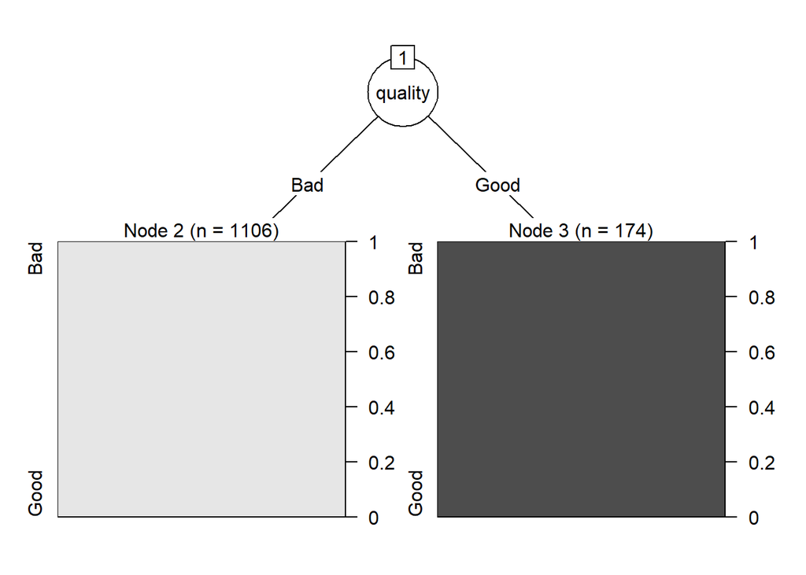

```r
plot(c5BoostModel)
```

```r
c5prediction <- predict(c5BoostModel, testData)
confusionMatrix(as.factor(c5prediction),as.factor(TestLabels))
```

```
## Confusion Matrix and Statistics
##
##           Reference
## Prediction Bad Good
##       Bad  276    0
##       Good   0   43
##
##                Accuracy : 1
##                  95% CI : (0.9885, 1)
##     No Information Rate : 0.8652
##     P-Value [Acc > NIR] : < 2.2e-16
##
##                   Kappa : 1
##
##  Mcnemar's Test P-Value : NA
##
##             Sensitivity : 1.0000
##             Specificity : 1.0000
##          Pos Pred Value : 1.0000
##          Neg Pred Value : 1.0000
##              Prevalence : 0.8652
##          Detection Rate : 0.8652
##    Detection Prevalence : 0.8652
##       Balanced Accuracy : 1.0000
##
##        'Positive' Class : Bad
##
```